# Exploring Bus Occupancy and Activities: A Journey Through Punctuality and Passengers

Michka Kangsathien

## Introduction

In this analysis, we explore how bus occupancy is influenced by various factors, such as punctuality and the activities passengers are engaged in. We’ll look at data from bus journeys to uncover patterns in the number of passengers and how they interact with the bus environment.

## Most Common Activities on the Bus

We explore the most common activities passengers are engaged in while on the bus. The bar chart below categorizes these activities to identify what passengers typically do during their journeys.

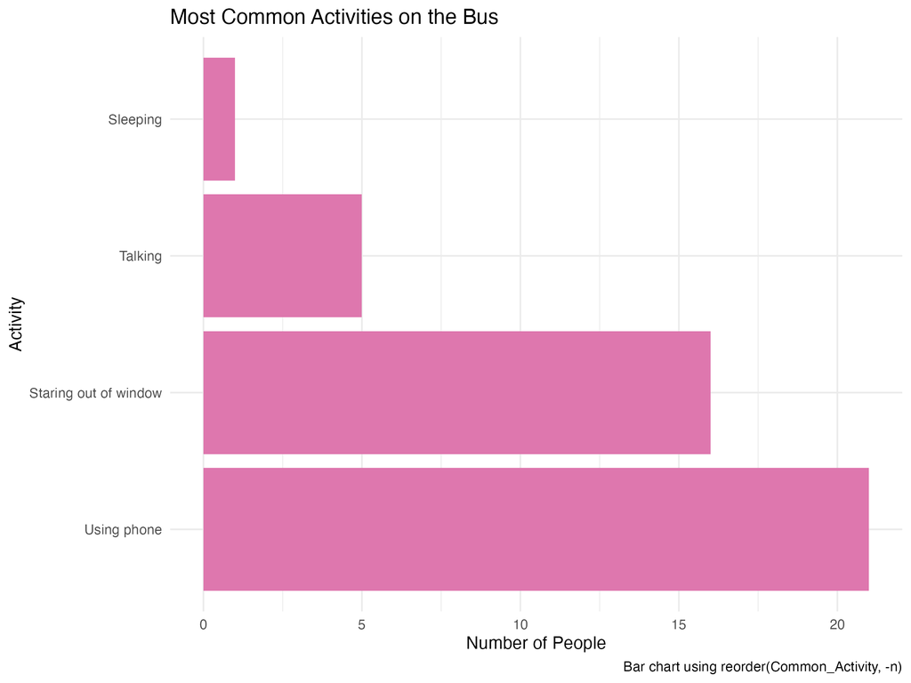

This section explores the specific activities that passengers reported seeing most frequently on the bus. Instead of grouping responses, we analysed the exact phrases provided to see which activities stood out the most.

## Bus Occupancy by Punctuality

The box and whisker plot below shows how the number of people on the bus varies depending on how punctual the bus was.

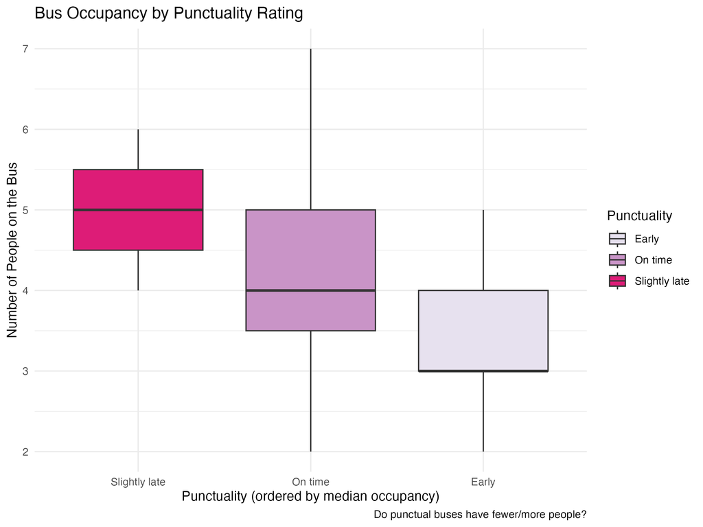

*Alt text: A box and whisker plot showing the number of people on the bus, grouped by bus punctuality ratings.*

The plot shows that buses with higher occupancy levels tend to arrive late, likely because they take longer to pick up and drop off more passengers. In contrast, less crowded buses are generally more punctual. Understanding this relationship can inform better scheduling and crowd management on public transport.

## Categorized Activities on the Bus

To further refine our understanding, we categorize the activities into broader groups such as “Phone-related,” “Inactive,” and “Socializing.” The following chart provides a clearer view of these categories and the number of passengers in each.

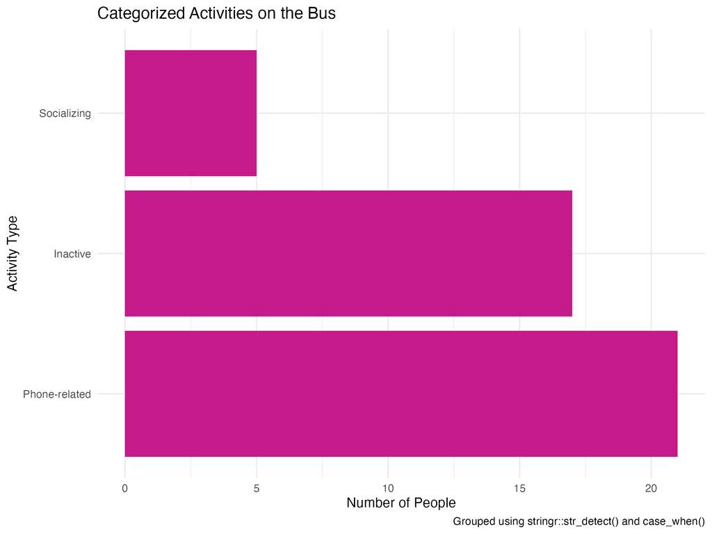

Catergorized Activites on the Bus

*Alternative text: This bar chart categorizes passenger activities into broader groups like “Phone-related,” “Inactive,” and “Socializing.” The y-axis represents the activity types, while the x-axis shows the number of passengers in each category. This allows us to see how many passengers engage in phone use, remain inactive, or socialize during their bus ride.Phone-related activities are most frequent, followed by inactive and socializing categories.*

To better understand passenger behavior, we analyzed responses to the question: “What was the most common activity people were doing on the bus?” Activities were grouped into broader categories using text pattern recognition techniques.

The bar chart below shows that phone-related activities (e.g., texting, scrolling, or making calls) are the most common. This is followed by inactive behavior such as sitting quietly or staring out the window, and socializing through talking or chatting. This suggests that while many passengers are engaged with their devices, a significant portion remain passive or interact with others.

Understanding what people commonly do while commuting on the bus connects to broader social and urban trends. For example:

Digital device use (“on their phone”) reflects our increasingly mobile and connected lifestyles. It suggests passengers are using commute time to check messages, scroll social media, or catch up on work or entertainment.

“Looking out the window” or “sleeping” may indicate that some passengers use the time to rest or unwind, highlighting how public transport can be a moment of pause in busy urban routines.

Social interactions like “talking to someone” hint at how public spaces like buses can still foster real-world connection, despite the rise in digital engagement.

From a public transport planning perspective, knowing how people spend their time on the bus can inform decisions around:

Improving ride comfort (e.g., stable Wi-Fi, better seating)

Reducing crowding for a more relaxing journey

Promoting digital services or health messaging that passengers can engage with during travel